# Multivariate Distributions

## Recall

**Q:** Suppose the folling table of probabilities described the computer type and operating system choices for the Vanderbilt student population.

| Product | Apple OS | Windows OS |  |
| --- | --- | --- | --- |
| Laptop | a | b | .80 |
| Desktop | c | .15 | d |
|  | .60 | e | f |

## Solution

**Q:** Suppose the folling table of probabilities described the computer type and operating system choices for the Vanderbilt student population.

| Product | Apple OS | Windows OS |  |
| --- | --- | --- | --- |
| Laptop | .55 | .25 | .80 |
| Desktop | .05 | .15 | .20 |
|  | .60 | .40 | 1 |

## Also recall

**Q:** Suppose the folling table of probabilities described the computer type and operating system choices for the Vanderbilt student population.

| Product | Apple OS | Windows OS |  |
| --- | --- | --- | --- |
| Laptop | a | b | .80 |
| Desktop | c | d | e |
|  | f | g | h |

- \(P(\text{Apple OS} | \text{Laptop}) = .8\)
- \(P(\text{Apple OS} | \text{Desktop}) = .3\)

## Solution

**Q:** Suppose the folling table of probabilities described the computer type and operating system choices for the Vanderbilt student population.

| Product | Apple OS | Windows OS |  |
| --- | --- | --- | --- |
| Laptop | .64 | .16 | .80 |
| Desktop | .06 | .14 | .20 |
|  | .70 | .30 | 1 |

- \(P(\text{Apple OS} | \text{Laptop}) = .8\)
- \(P(\text{Apple OS} | \text{Desktop}) = .3\)

## Recall

We used the properties of probabilities to uncover the joint distribution.

\[ P(A = a,\ B = b) = P(B = b)\, P(A = a\, |\, B = b)\\ P(A = a,\ B = b) = P(A = a)\, P(B = b\, |\, A = a) \]

\[ P(A = a) = \sum_{\begin{array}{c}j\ =\ \text{all}\\ \text{values} \\ \text{of B}\end{array}} P(A = a \text{ and } B = j)\] \[ P(A = a) = \sum_{\begin{array}{c}j\ =\ \text{all}\\ \text{values} \\ \text{of B}\end{array}} P(B = j)\,P(A = a | B = j)\]

## Uncovering the joint distribution

Uncovering the joint distribution allows one to:

- Understand the relationship between outcomes \(A\) and \(B\)
- Use information about \(B\) to predict \(A\) (or vica versa)

## **Today:** Joint distributions of continuous variables Chapter 11

## Motivating example: Univariate Normal

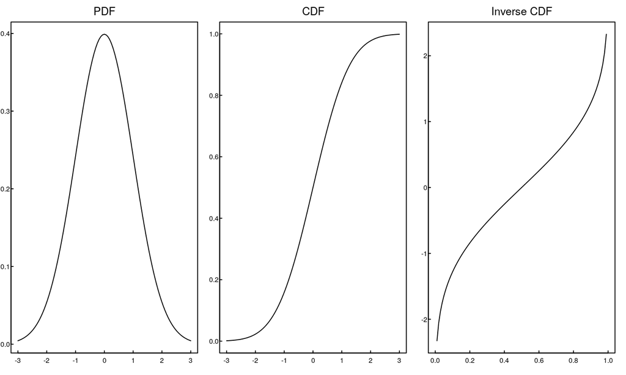

## Motivating example: Bivariate Normal

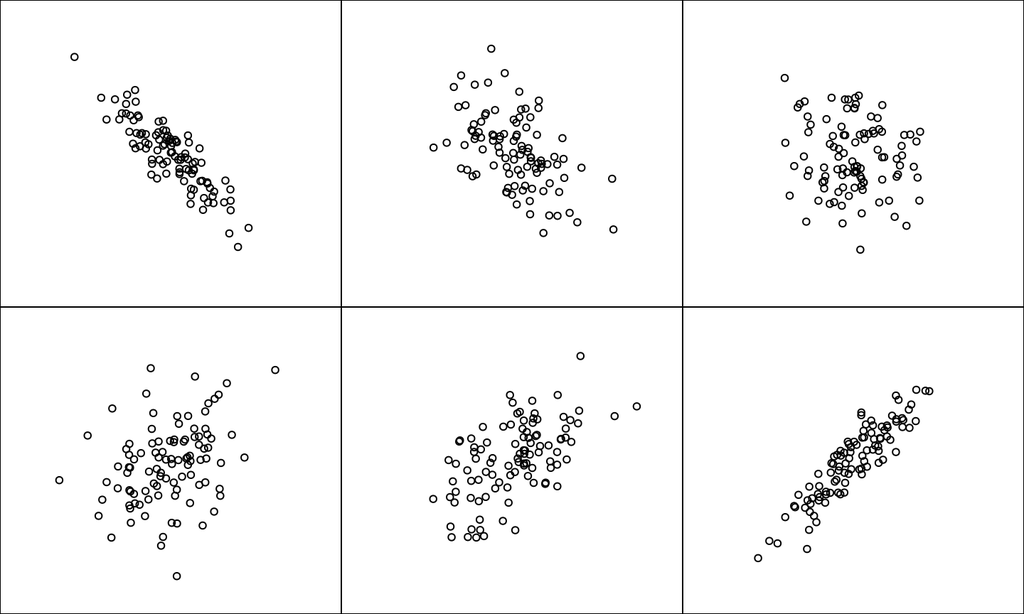

## Univariate vs Bivariate

| Univariate | Bivariate |
| --- | --- |
| \(F_X(x) = P(X\leq x)\) | \(F_{X,Y}(x,y) = P(X\leq x\ \text{and}\ Y\leq y)\) |
| \(f_X(x) = \frac{d}{dx} F_X(x)\) | \(f_{X,Y}(x,y) = \frac{\partial^2}{\partial x \partial y} F_{X,Y}(x,y)\) |

## Univariate vs Bivariate

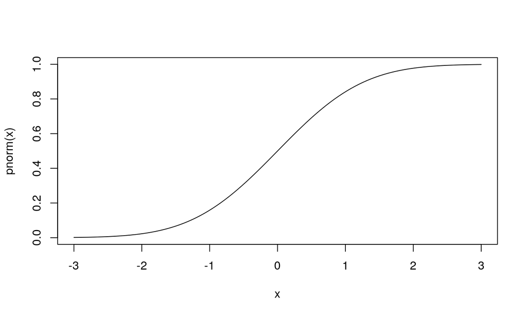

## Univariate vs Bivariate

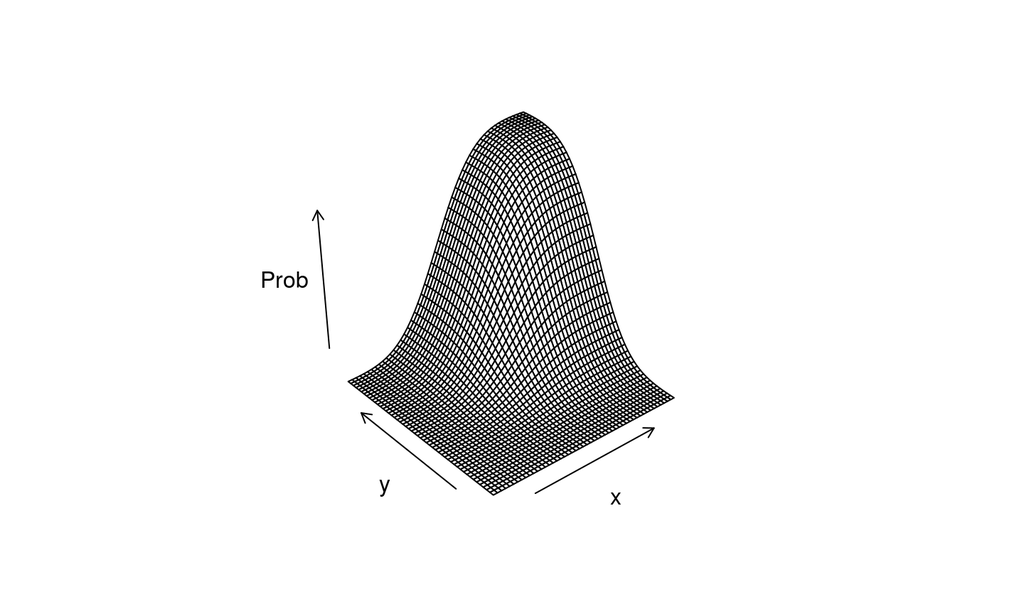

## Univariate vs Bivariate

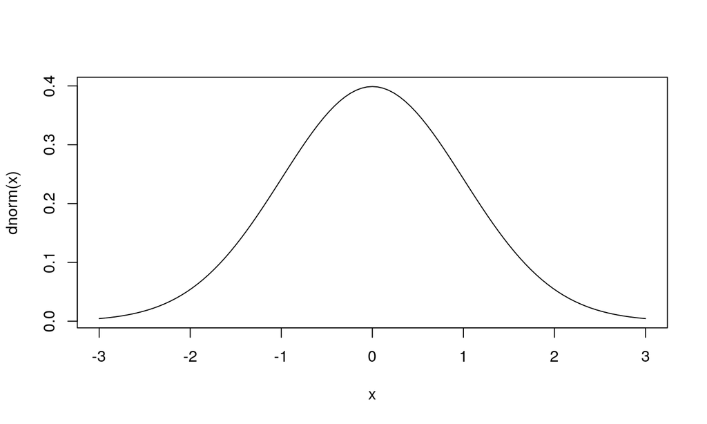

## Univariate vs Bivariate

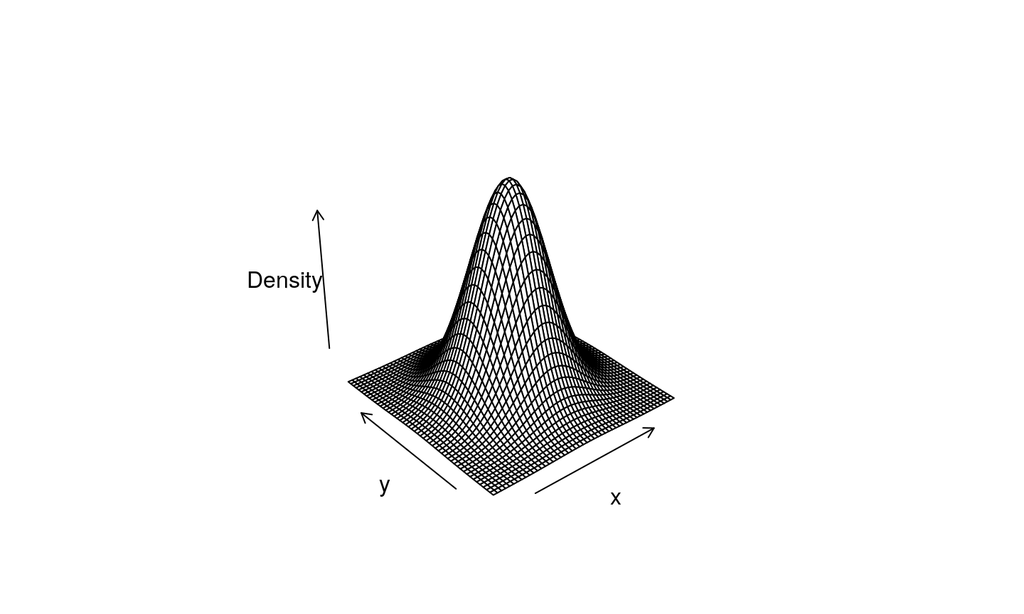

## Covariance

A measure of linear association

\[ Cov(X,Y) = E[(X - E[X])(Y - E[y])]\]

## Covariance

A measure of linear association

\[ Cov(X,Y) = E[XY] - E[X]E[Y]\]

## Covariance

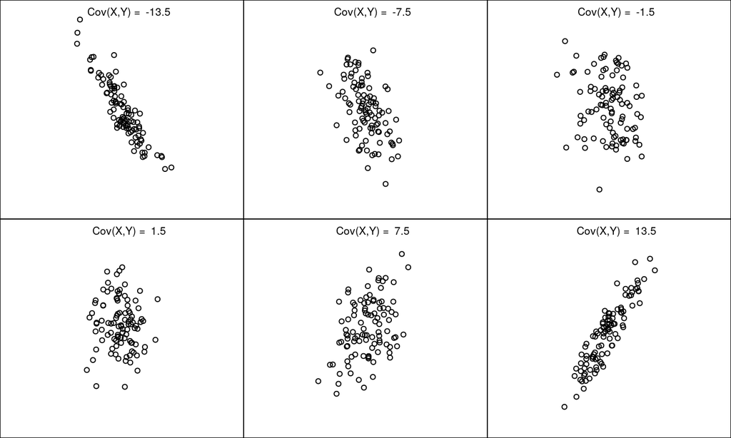

## Sample covariance

\[ \widehat{Cov}(X,Y) = \frac{1}{N} \sum_{i=1}^N (X_i - \bar{X})(Y_i - \bar{Y}) \]

## Sample covariance in NHANES

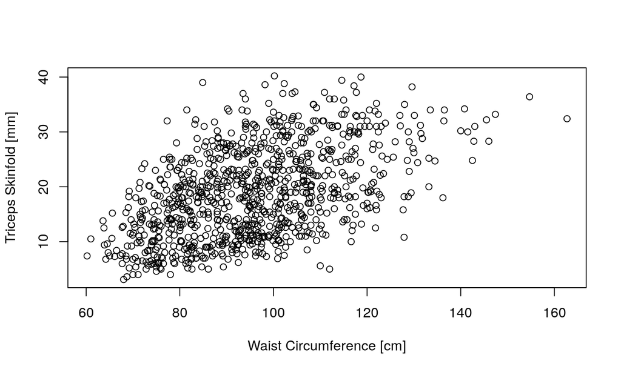

```r
Hmisc::getHdata(nhgh)
sn <- nhgh[1:1000,]
plot(sn$waist, sn$tri, ylab = "Triceps Skinfold [mm]", xlab = "Waist Circumference [cm]")
```

## Sample covariance in NHANES

| waist | tri |
| --- | --- |
| 100.4 | 16.4 |
| 74.7 | 10.2 |
| 118.2 | 29.6 |
| 103.7 | 19.0 |
| 107.8 | 30.3 |
| 91.1 | 8.6 |

## Sample covariance in NHANES

| waist | waist_centered | tri | tri_centered |
| --- | --- | --- | --- |
| 100.4 | 3.86 | 16.4 | -2.49 |
| 74.7 | -21.84 | 10.2 | -8.69 |
| 118.2 | 21.66 | 29.6 | 10.71 |
| 103.7 | 7.16 | 19.0 | 0.11 |
| 107.8 | 11.26 | 30.3 | 11.41 |
| 91.1 | -5.44 | 8.6 | -10.29 |

## Sample covariance in NHANES

| waist | waist_centered | tri | tri_centered | waist_centered_tri_centered |
| --- | --- | --- | --- | --- |
| 100.4 | 3.86 | 16.4 | -2.49 | -9.6114 |
| 74.7 | -21.84 | 10.2 | -8.69 | 189.7896 |
| 118.2 | 21.66 | 29.6 | 10.71 | 231.9786 |
| 103.7 | 7.16 | 19.0 | 0.11 | 0.7876 |
| 107.8 | 11.26 | 30.3 | 11.41 | 128.4766 |
| 91.1 | -5.44 | 8.6 | -10.29 | 55.9776 |

## Sample covariance in NHANES

```r
mean(sn$waist_centered_tri_centered, na.rm = TRUE)
```

```
## [1] 66.02871
```

## Sample covariance in NHANES

```r
cov(sn[,c("waist","tri")], use = "complete.obs")
```

```
##           waist      tri
## waist 266.27138 66.07489
## tri    66.07489 66.12120
```

## How might one generate a confidence interval for the covariance?

> **Related question:** How might one generate the sampling distribution for the covariance?

## How might one generate a confidence interval for the covariance?

### Bootstrap

```r
R <- 5000
out <- rep(NA, R)
for(i in 1:R){
  rows <- sample.int(nrow(sn), nrow(sn), replace = TRUE)
  new_sample <- sn[rows, ]
  out[i] <- cov(new_sample[,c("waist","tri")], use = "complete")[1,2]
}
quantile(out, c(0.05/2, 1-0.05/2))
```

## How might one generate a confidence interval for the covariance?

### Bootstrap

```
##     2.5%    97.5%
## 57.18068 74.82760
```

## How might one generate a confidence interval for the covariance?

### Central Limit Theorem

\[ \widehat{Cov}(X,Y) = \frac{1}{N} \sum_{i=1}^N (X_i - \bar{X})(Y_i - \bar{Y}) \]

> Are the observations independent?

## How might one generate a confidence interval for the covariance?

### Central Limit Theorem

```r
Nobs <- sum(!is.na(sn$waist_centered_tri_centered))
sample_mean <- mean(sn$waist_centered_tri_centered, na.rm = TRUE)
sample_var <- var(sn$waist_centered_tri_centered, na.rm = TRUE)
sample_mean + qnorm(c(0.05/2, 1-0.05/2)) * sqrt(sample_var)/sqrt(Nobs)
```

## How might one generate a confidence interval for the covariance?

### Central Limit Theorem

```
## [1] 57.16474 74.89267
```

## Correlation

A standardized measure of linear association

\[\rho(X,Y) = Cor(X,Y) = \frac{Cov(X,Y)}{\sqrt{V[X]V[Y]}}\]

## Correlation

A standardized measure of linear association

- \(-1\leq \rho(X,Y)\leq 1\)
- \(|\rho(X,Y)| = 1\) if and only if \(X\) and \(Y\) are exact linear functions of each other.

## Example

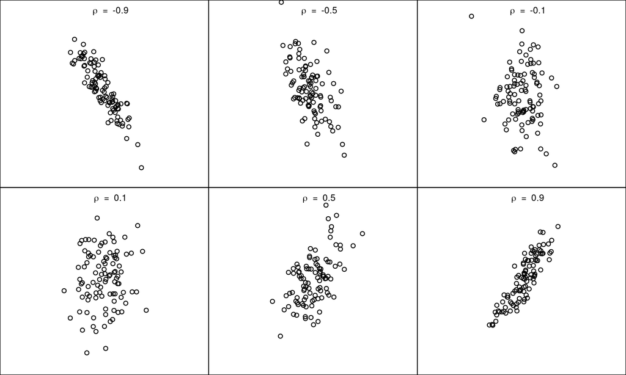

## Sample Correlation

\[ \hat{\rho}(X,Y) = \frac{\widehat{Cov}(X,Y)}{s_X\ s_Y} \]

## Sample Correlation in R

```r
cor(sn[,c("waist","tri")], use = "complete")
```

```
##           waist       tri
## waist 1.0000000 0.4979708
## tri   0.4979708 1.0000000
```

## How might one generate a confidence interval for the correlation?

> **Related question:** How might one generate the sampling distribution for the covariance?

## How might one generate a confidence interval for the correlation?

### Bootstrap

```r
R <- 5000
out <- rep(NA, R)
for(i in 1:R){
  rows <- sample.int(nrow(sn), nrow(sn), replace = TRUE)
  new_sample <- sn[rows, ]
  out[i] <- cor(new_sample[,c("waist","tri")], use = "complete")[1,2]
}
quantile(out, c(0.05/2, 1-0.05/2))
```

## How might one generate a confidence interval for the correlation?

### Bootstrap

```
##      2.5%     97.5%
## 0.4510887 0.5418869
```

## How might one generate a confidence interval for the correlation?

### Central Limit Theorem

\[ \hat{\rho}(X,Y) = \frac{1}{N} \sum_{i=1}^N \frac{(X_i - \bar{X})}{s_X}\frac{(Y_i - \bar{Y})}{s_Y} \]

> Are the observations independent?

## How might one generate a confidence interval for the correlation?

### Central Limit Theorem

```r
sn_center_scaled <- scale(sn[,c("waist","tri")])
waist_tri_centered_scaled <- sn_center_scaled %>% apply(1,prod)
sample_mean <- mean(waist_tri_centered_scaled, na.rm = TRUE)
sample_var <- var(waist_tri_centered_scaled, na.rm = TRUE)
Nobs <- sum(!is.na(waist_tri_centered_scaled))

sample_mean + qnorm(c(0.05/2, 1-0.05/2)) * sqrt(sample_var)/sqrt(Nobs)
```

## How might one generate a confidence interval for the correlation?

### Central Limit Theorem

[output not shown]

## How might one generate a confidence interval for the correlation?

### Central Limit Theorem

```r
cor.test(sn$waist, sn$tri)
```

```
##
##  Pearson's product-moment correlation
##
## data:  sn$waist and sn$tri
## t = 17.465, df = 925, p-value < 2.2e-16
## alternative hypothesis: true correlation is not equal to 0
## 95 percent confidence interval:
##  0.4479447 0.5448884
## sample estimates:
##       cor
## 0.4979708
```